BCG Gamma - Datathlon

*Equipe CS Delivery : Matthias Lesage, Julien Pinède, Soukaina Lidam, Carlos Santos García, Timothé Chaumont et Tony Wu*

[figure not shown]

# Introduction

Ce Datathon est une collaboration entre BCG Gamma et CentraleSupélec. Sous une forme accélérée, il est une opportunité de découvrir un projet de stratégie avec une dimension DataScience.

L’étude de cas présente pour client une entreprise française opérant principalement en région parisienne du nom de *LivraisonCo*. Le CEO de cette firme désire optimiser le processus de livraison de colis. La première étape consistait à prédire l’état de trafic, puis dans un deuxième temps d'exploiter cette donnée pour définir une stratégie d’optimisation. Avec une équipe de profils diversifiés, nous avons commencé par définir nos objectifs et à spécifier le besoin. Sur le plan technique, nous avons fait un nettoyage des données et une intégration de données externes jugées utiles (météo, mesures sanitaires…) puis un test de différents modèles naïfs et complexes qui ont fourni des résultats variables. Enfin, nous avons décidé du modèle à garder et avons généré les prédictions demandées du 11 décembre au 16 décembre 2020.

Les parties 2 à 6 montrent en détail le pre-processing des données. Il est néanmoins possible de commencer la lecture des la [partie 7](http://localhost:8888/notebooks/Other%20Documents/bcg-gamma-project/final_notebook.ipynb#Pipeline-de-synthèse) qui présente la pipeline de synthèse.

**Remarques :**

- Pour profiter de toutes les fonctionnalités de ce noteboook, utiliser Chrome, Firefox ou Edge
- Nous vous recommandons aussi d'utiliser l'extension *Table of Contents* pour naviguer plus facilement dans ce notebook
- Les fichiers ayant servi à choisir et tester nos modèles sont dans `data/data_for_baseline`, à ne pas confondre avec les fichiers présents directement dans `data` qui nous ont servis à faire nos prédictions pour le challenge.

[figure not shown]

# Imports des modules

Avant de lancer la cellule suivante, il est conseillé de créer un nouvel environnement de la manière suivante :

```
conda env create --file conda_env.yml
```

```python
import os
import time
import datetime
import itertools
import warnings

import re

from functools import reduce

import numpy as np
import pandas as pd

import matplotlib.pyplot as plt
import seaborn as sns
from datetime import datetime

import statsmodels.api as sm
from pylab import rcParams
from statsmodels.tools.sm_exceptions import ConvergenceWarning
warnings.simplefilter('ignore', ConvergenceWarning) # Permet d'éviter l'affichage des Warnings

from sklearn.metrics import mean_squared_error

from tqdm import tqdm

from ipywidgets import interact, interactive, fixed, interact_manual
import ipywidgets as widgets
```

```python
from cleaning import *
```

Le code qui suit peut être intégralement retrouvé dans le fichier `cleaning.ipynb` qui contient l'ensemble du code ayant permis de générer le module `cleaning.py`. Ce notebook détaille toutes les étapes nécessaires au pré-traitement des données et à l'ajout des features supplémentaires utiles à notre objectif.

À titre d'illustration, ce code est également présenté ci-dessous.

Les données sont enregistrées dans 3 fichiers CSV différents. Elles portent les noms suivants :

- `champs-elysees.csv`
- `convention.csv`
- `sts.csv`.

Définissons quelques variables globales pour la suite.

```python
data_path = './data'
```

```python
list_filenames = ['champs-elysees.csv', 'convention.csv', 'sts.csv']
```

# Import des données

## Informations générales

**Les données ont été téléchargées depuis :**

- https://opendata.paris.fr/explore/dataset/comptages-routiers-permanents/information/?disjunctive.libelle&disjunctive.etat_trafic&disjunctive.libelle_nd_amont&disjunctive.libelle_nd_aval&sort=t_1h

**Lien de la notice d'obtention des features :**

- https://opendata.paris.fr/api/datasets/1.0/comptages-routiers-permanents/attachments/notice_donnes_trafic_capteurs_permanents_version_20190607_pdf/

**Quelques infos issues du site sur le dataset:**

> **Données de trafic routier issues des capteurs permanents sur 13 mois glissants en J-1**  
> Sur le réseau parisien, la mesure du trafic s’effectue majoritairement par le biais de boucles électromagnétiques implantés dans la chaussée.  
> La donnée est produite par la Direction de la Voirie et des déplacements - Service des Déplacements - Poste Central d'Exploitation Lutèce.  
> La donnée et les visualisations associées (Tableau, Carte et Dataviz) sont brutes sans aucune interprétation ou analyse. Elles donnent à voir la donnée telle qu'elle est publiée quotidiennement. Elles donnent un aperçu du taux d'occupation et du débit sur plus de 3000 tronçons de voies. A elles seules, elles ne permettent pas de caractériser la complexité de la circulation à Paris.  
> **Deux types de données sont ainsi élaborés :** le taux d’occupation, qui correspond au temps de présence de véhicules sur la boucle en pourcentage d’un intervalle de temps fixe (une heure pour les données fournies). Ainsi, 25% de taux d’occupation sur une heure signifie que des véhicules ont été présents sur la boucle pendant 15 minutes. Le taux fournit une information sur la congestion routière. L’implantation des boucles est pensée de manière à pouvoir déduire, d’une mesure ponctuelle, l’état du trafic sur un arc. le débit est le nombre de véhicules ayant passé le point de comptage pendant un intervalle de temps fixe (une heure pour les données fournies).  
> L'horodate horaire est effectué en fin de période d'élaboration. Par exemple, l’horodate « 2019-01-01 01:00:00 » désigne la période du 1er janvier 2019 à 00h00 au 1er janvier 2019 à 01h00.  
> Ainsi, l’observation couplée en un point du taux d’occupation et du débit permet de caractériser le trafic. Cela constitue l’un des fondements de l’ingénierie du trafic, et l’on nomme d’ailleurs cela le « diagramme fondamental ». Un débit peut correspondre à deux situations de trafic : fluide ou saturée, d’où la nécessité du taux d’occupation. A titre d’exemple : sur une heure, un débit de 100 véhicules par heure sur un axe habituellement très chargé peut se rencontrer de nuit (trafic fluide) ou bien en heure de pointe (trafic saturé).  
> **L’équipement du réseau parisien :**  
> Les principaux axes de la Ville de Paris sont équipés de stations de comptage des véhicules et de mesure du taux d’occupation, à des fins à la fois de régulation du trafic et des transports en commun, d’information aux usagers (diffusion sur le site Sytadin), et d’étude. Il existe deux types de stations sur le réseau : les stations de mesure du taux d’occupation seul, et des stations à la fois de mesure du taux et de comptage des véhicules. Les stations de mesure du taux sont implantées très régulièrement : elles permettent une connaissance fine des conditions de circulation. Les stations de débit sont moins nombreuses, et généralement implantées entre les principales intersections. En effet, le débit se conserve généralement sur une section entre deux grands carrefours.

## Lecture des CSV

On regroupera toutes les lignes des 3 CSV dans un même DataFrame. Une colonne filename y a été ajoutée pour facilement avoir l'origine de la ligne à portée de main.

```python
window = 14 # modifier si besoin la taille de la fenêtre

l_df = [pd.read_csv(
    os.path.join(data_path, filename),
    sep=';',
    index_col=0).assign(filename=filename) for filename in list_filenames]

for idx, df in enumerate(l_df):
    df = df.sort_values("Date et heure de comptage")
    df['Débit horaire'] = df['Débit horaire'].interpolate()
    df["Taux d'occupation"] = df["Taux d'occupation"].interpolate()

    l_df[idx] = df
```

```python
df = pd.concat(l_df, ignore_index=True)

df.sample(5)
```

|  | Libelle | Date et heure de comptage | Débit horaire | Taux d'occupation | Etat trafic | Identifiant noeud amont | Libelle noeud amont | Identifiant noeud aval | Libelle noeud aval | Etat arc | Date debut dispo data | Date fin dispo data | geo_point_2d | geo_shape | filename |
| --- | --- | --- | --- | --- | --- | --- | --- | --- | --- | --- | --- | --- | --- | --- | --- |
| 230610 | Sts_Peres | 2020-08-15T19:00:00+02:00 | 357.0 | 2.85500 | Fluide | 119 | Sts_Peres-Universite | 120 | Bd_St_Germain-Sts_Peres | Invalide | 2005-01-01 | 2019-06-01 | 48.8553754186,2.33103664165 | {"type": "LineString", "coordinates": [[2.3316... | sts.csv |
| 135997 | Convention | 2020-07-23T06:00:00+02:00 | 38.0 | 1.30611 | Fluide | 2966 | Convention-St_Charles | 2967 | Convention-Lourmel | Invalide | 2005-01-01 | 2019-06-01 | 48.8427659306,2.28419855155 | {"type": "LineString", "coordinates": [[2.2828... | convention.csv |
| 2519 | AV_Champs_Elysees | 2020-02-14T03:00:00+01:00 | 433.0 | 5.62611 | Fluide | 2294 | Av_Champs_Elysees-Washington | 2293 | Av_Champs_Elysees-Berri | Invalide | 2005-01-01 | 2019-06-01 | 48.8715358799,2.30172279246 | {"type": "LineString", "coordinates": [[2.3009... | champs-elysees.csv |
| 123860 | Convention | 2020-06-27T02:00:00+02:00 | 404.0 | 1.88389 | Fluide | 2969 | Convention-Croix_Nivert | 2937 | Lecourbe-Convention | Invalide | 2005-01-01 | 2019-06-01 | 48.8396188347,2.29108559823 | {"type": "LineString", "coordinates": [[2.2902... | convention.csv |
| 75950 | Convention | 2020-03-19T06:00:00+01:00 | 25.0 | 0.34556 | Fluide | 2975 | Place_Charles_Valin | 2974 | Convention-Olivier_de_Serres | Invalide | 2005-01-01 | 2019-06-01 | 48.8361218455,2.30026304068 | {"type": "LineString", "coordinates": [[2.3025... | convention.csv |

```python
df.isna().sum()
```

```
Libelle                      0
Date et heure de comptage    0
Débit horaire                1
Taux d'occupation            0
Etat trafic                  0
Identifiant noeud amont      0
Libelle noeud amont          0
Identifiant noeud aval       0
Libelle noeud aval           0
Etat arc                     0
Date debut dispo data        0
Date fin dispo data          0
geo_point_2d                 0
geo_shape                    0
filename                     0
dtype: int64
```

## Filtrage par noeud

```python
df = df.drop(columns=[
    'Identifiant noeud amont', 'Identifiant noeud aval', 'geo_point_2d',
    'geo_shape', 'Date debut dispo data', 'Date fin dispo data'
])
```

```python
# Contient pour chaque fichier CSV un 2-tuple de la forme (noeud_amont, noeud_aval)
dic_noeuds = {
    'champs-elysees.csv': ('Av_Champs_Elysees-Washington', 'Av_Champs_Elysees-Berri'),
    'convention.csv': ('Lecourbe-Convention', 'Convention-Blomet'),
    'sts.csv': ('Sts_Peres-Voltaire', 'Sts_Peres-Universite')
}
```

```python
list_criteria = []
for key, val in dic_noeuds.items():
    criterion = (df['filename']==key) & (df['Libelle noeud amont']==val[0]) & (df['Libelle noeud aval']==val[1])
    list_criteria.append(criterion)

criterion_noeuds = reduce(lambda x, y: x | y, list_criteria)

print(f'Taille du df avant filtrage: {len(df)}')
df = df[criterion_noeuds]
print(f'Taille du df après filtrage: {len(df)}')
```

```
Taille du df avant filtrage: 241768
Taille du df après filtrage: 29009
```

On peut désormais drop les libellés.

```python
df = df.drop(columns=['Libelle noeud amont', 'Libelle noeud aval'])
df.head()
```

|  | Libelle | Date et heure de comptage | Débit horaire | Taux d'occupation | Etat trafic | Etat arc | filename |
| --- | --- | --- | --- | --- | --- | --- | --- |
| 0 | AV_Champs_Elysees | 2019-11-01T04:00:00+01:00 | 746.0 | 10.98889 | Fluide | Invalide | champs-elysees.csv |
| 1 | AV_Champs_Elysees | 2019-11-01T05:00:00+01:00 | 549.0 | 7.40722 | Fluide | Invalide | champs-elysees.csv |
| 2 | AV_Champs_Elysees | 2019-11-01T06:00:00+01:00 | 503.0 | 7.66667 | Fluide | Invalide | champs-elysees.csv |
| 3 | AV_Champs_Elysees | 2019-11-01T07:00:00+01:00 | 500.0 | 4.75500 | Fluide | Invalide | champs-elysees.csv |
| 4 | AV_Champs_Elysees | 2019-11-01T08:00:00+01:00 | 525.0 | 5.37389 | Fluide | Invalide | champs-elysees.csv |

```python
df['filename'].unique()
```

```
array(['champs-elysees.csv', 'convention.csv', 'sts.csv'], dtype=object)
```

# Preprocessing des données

## Conversion en datetime

```python
df.dtypes
```

```
Libelle                       object
Date et heure de comptage     object
Débit horaire                float64
Taux d'occupation            float64
Etat trafic                   object
Etat arc                      object
filename                      object
dtype: object
```

```python
df['Date et heure de comptage']
```

```
0         2019-11-01T04:00:00+01:00
1         2019-11-01T05:00:00+01:00
2         2019-11-01T06:00:00+01:00
3         2019-11-01T07:00:00+01:00
4         2019-11-01T08:00:00+01:00
                    ...
241748    2020-12-10T20:00:00+01:00
241752    2020-12-10T21:00:00+01:00
241756    2020-12-10T22:00:00+01:00
241762    2020-12-10T23:00:00+01:00
241764    2020-12-11T00:00:00+01:00
Name: Date et heure de comptage, Length: 29009, dtype: object
```

‼️ Il semble y avoir un soucis de timezone pour les capteurs... ‼️

**Hypothèse:** On ca supposer que l'heure UTC est la bonne pour la suite.

```python
def remove_timezone(row):
    return row.tz_localize(None)
```

```python
df['Date et heure de comptage'] = pd.to_datetime(df['Date et heure de comptage'], utc=True)
df['Date et heure de comptage'] = df['Date et heure de comptage'].apply(remove_timezone)
df['Date et heure de comptage']
```

```
0        2019-11-01 03:00:00
1        2019-11-01 04:00:00
2        2019-11-01 05:00:00
3        2019-11-01 06:00:00
4        2019-11-01 07:00:00
                 ...
241748   2020-12-10 19:00:00
241752   2020-12-10 20:00:00
241756   2020-12-10 21:00:00
241762   2020-12-10 22:00:00
241764   2020-12-10 23:00:00
Name: Date et heure de comptage, Length: 29009, dtype: datetime64[ns]
```

On a pour l'instant l'heure UTC. Nous allons nous replacer à l'heure de Paris pour la suite, pour des questions pratiques.

```python
df.dtypes
```

```
Libelle                              object
Date et heure de comptage    datetime64[ns]
Débit horaire                       float64
Taux d'occupation                   float64
Etat trafic                          object
Etat arc                             object
filename                             object
dtype: object
```

On rajoute 1 heure pour revenir à l'heure de Paris.

```python
df['Date et heure de comptage'] = df['Date et heure de comptage'] + pd.DateOffset(hours=1)
df['Date et heure de comptage']
```

```
0        2019-11-01 04:00:00
1        2019-11-01 05:00:00
2        2019-11-01 06:00:00
3        2019-11-01 07:00:00
4        2019-11-01 08:00:00
                 ...
241748   2020-12-10 20:00:00
241752   2020-12-10 21:00:00
241756   2020-12-10 22:00:00
241762   2020-12-10 23:00:00
241764   2020-12-11 00:00:00
Name: Date et heure de comptage, Length: 29009, dtype: datetime64[ns]
```

```python
date_begin = df['Date et heure de comptage'].min().strftime('%d/%m/%Y')
date_end = df['Date et heure de comptage'].max().strftime('%d/%m/%Y')
print(f'Première mesure de comptage prise : {date_begin}')
print(f'Dernière mesure de comptage prise : {date_end}')
```

```
Première mesure de comptage prise : 01/11/2019
Dernière mesure de comptage prise : 11/12/2020
```

## Analyse et visualisation (avant nettoyage)

```python
df[['Débit horaire', "Taux d'occupation"]].describe()
```

|  | Débit horaire | Taux d'occupation |
| --- | --- | --- |
| count | 29009.000000 | 29009.000000 |
| mean | 543.231390 | 8.290648 |
| std | 369.049997 | 9.482874 |
| min | 0.000000 | 0.000000 |
| 25% | 201.000000 | 1.790560 |
| 50% | 508.000000 | 4.921110 |
| 75% | 841.000000 | 11.050560 |
| max | 1610.000000 | 84.668890 |

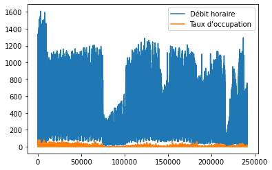

```python
df[['Débit horaire', "Taux d'occupation"]].plot()
```

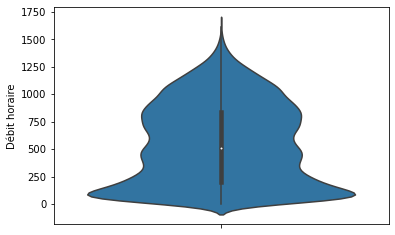

```python
sns.violinplot(y='Débit horaire', data=df)
```

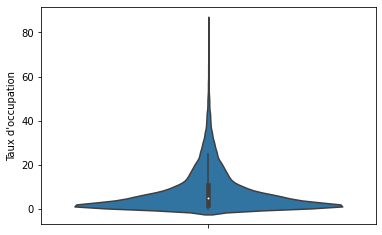

```python
sns.violinplot(y="Taux d'occupation", data=df)
```

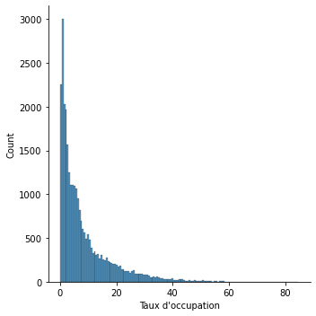

```python
sns.displot(df, x="Taux d'occupation")
```

## Feature engineering

### Categorical variables

Ajoutons un *one-hot encoding* pour les variables catégoriques. On n'oubliera cependant pas de passer à un *dummy encoding* avant d'entraîner le modèle pour éviter un problème de dimension. ‼️

```python
df.dtypes
```

```
Libelle                              object
Date et heure de comptage    datetime64[ns]
Débit horaire                       float64
Taux d'occupation                   float64
Etat trafic                          object
Etat arc                             object
filename                             object
dtype: object
```

**Ordinal encoding :**

Il semble en réalité plus pertinent d'utiliser un *ordinal encoding* pour donner une relation d'ordre à la feature. On se servira pour cela des informations contenues dans la notice.

[figure not shown]

```python
 df['Etat trafic']
```

```
0         Fluide
1         Fluide
2         Fluide
3         Fluide
4         Fluide
           ...
241748    Fluide
241752    Fluide
241756    Fluide
241762    Fluide
241764    Fluide
Name: Etat trafic, Length: 29009, dtype: object
```

```python
mapper = {'Inconnu': 0, 'Fluide': 1, 'Pré-saturé': 2, 'Saturé': 3, 'Bloqué': 4}
df['Etat trafic'] = df['Etat trafic'].map(mapper)
df.sample(5)
```

|  | Libelle | Date et heure de comptage | Débit horaire | Taux d'occupation | Etat trafic | Etat arc | filename |
| --- | --- | --- | --- | --- | --- | --- | --- |
| 223655 | Sts_Peres | 2020-06-03 09:00:00 | 558.0 | 7.01556 | 1 | Invalide | sts.csv |
| 1206 | AV_Champs_Elysees | 2019-12-21 10:00:00 | 866.0 | 13.77611 | 1 | Invalide | champs-elysees.csv |
| 61716 | Convention | 2020-02-17 14:00:00 | 800.0 | 6.75611 | 1 | Invalide | convention.csv |
| 7819 | AV_Champs_Elysees | 2020-09-23 23:00:00 | 652.0 | 6.53833 | 1 | Invalide | champs-elysees.csv |
| 66438 | Convention | 2020-02-27 10:00:00 | 891.0 | 16.78056 | 2 | Invalide | convention.csv |

### Features liées aux timestamp

Ajout du jour (sans l'heure) :

```python
df['Date'] = pd.to_datetime(df["Date et heure de comptage"]).dt.date
df.sample(5)
```

|  | Libelle | Date et heure de comptage | Débit horaire | Taux d'occupation | Etat trafic | Etat arc | filename | Date |
| --- | --- | --- | --- | --- | --- | --- | --- | --- |
| 76475 | Convention | 2020-03-20 08:00:00 | 302.0 | 2.25722 | 1 | Invalide | convention.csv | 2020-03-20 |
| 157304 | Convention | 2020-09-05 14:00:00 | 586.0 | 16.43611 | 2 | Invalide | convention.csv | 2020-09-05 |
| 7696 | AV_Champs_Elysees | 2020-09-18 20:00:00 | 1091.0 | 14.85889 | 1 | Invalide | champs-elysees.csv | 2020-09-18 |
| 80308 | Convention | 2020-03-28 08:00:00 | 146.0 | 1.00723 | 1 | Invalide | convention.csv | 2020-03-28 |
| 218981 | Sts_Peres | 2020-04-15 17:00:00 | 141.0 | 1.62945 | 1 | Invalide | sts.csv | 2020-04-15 |

Ajout du jour de la semaine:

```python
df['Jour de la semaine'] = pd.to_datetime(df["Date et heure de comptage"]).dt.dayofweek
df.sample(5)
```

|  | Libelle | Date et heure de comptage | Débit horaire | Taux d'occupation | Etat trafic | Etat arc | filename | Date | Jour de la semaine |
| --- | --- | --- | --- | --- | --- | --- | --- | --- | --- |
| 105768 | Convention | 2020-05-20 09:00:00 | 756.0 | 5.72945 | 1 | Invalide | convention.csv | 2020-05-20 | 2 |
| 6598 | AV_Champs_Elysees | 2020-08-04 02:00:00 | 362.0 | 4.19056 | 1 | Invalide | champs-elysees.csv | 2020-08-04 | 1 |
| 90827 | Convention | 2020-04-19 05:00:00 | 26.0 | 0.12778 | 1 | Invalide | convention.csv | 2020-04-19 | 6 |
| 3620 | AV_Champs_Elysees | 2020-04-01 00:00:00 | 23.0 | 0.30778 | 1 | Invalide | champs-elysees.csv | 2020-04-01 | 2 |
| 133358 | Convention | 2020-07-17 17:00:00 | 1085.0 | 9.69444 | 1 | Invalide | convention.csv | 2020-07-17 | 4 |

Reste maintenant à one-hot encoder cette variable.  
‼️ On pensera à drop un des 7 jours pour éviter des problèmes d'overfitting ‼️

```python
df = pd.concat([
    df,
    pd.get_dummies(df['Jour de la semaine'],
                   prefix='Jour de la semaine',
                   drop_first=False)
], axis=1).drop(columns=['Jour de la semaine'])

df.head()
```

|  | Libelle | Date et heure de comptage | Débit horaire | Taux d'occupation | Etat trafic | Etat arc | filename | Date | Jour de la semaine_0 | Jour de la semaine_1 | Jour de la semaine_2 | Jour de la semaine_3 | Jour de la semaine_4 | Jour de la semaine_5 | Jour de la semaine_6 |
| --- | --- | --- | --- | --- | --- | --- | --- | --- | --- | --- | --- | --- | --- | --- | --- |
| 0 | AV_Champs_Elysees | 2019-11-01 04:00:00 | 746.0 | 10.98889 | 1 | Invalide | champs-elysees.csv | 2019-11-01 | 0 | 0 | 0 | 0 | 1 | 0 | 0 |
| 1 | AV_Champs_Elysees | 2019-11-01 05:00:00 | 549.0 | 7.40722 | 1 | Invalide | champs-elysees.csv | 2019-11-01 | 0 | 0 | 0 | 0 | 1 | 0 | 0 |
| 2 | AV_Champs_Elysees | 2019-11-01 06:00:00 | 503.0 | 7.66667 | 1 | Invalide | champs-elysees.csv | 2019-11-01 | 0 | 0 | 0 | 0 | 1 | 0 | 0 |
| 3 | AV_Champs_Elysees | 2019-11-01 07:00:00 | 500.0 | 4.75500 | 1 | Invalide | champs-elysees.csv | 2019-11-01 | 0 | 0 | 0 | 0 | 1 | 0 | 0 |
| 4 | AV_Champs_Elysees | 2019-11-01 08:00:00 | 525.0 | 5.37389 | 1 | Invalide | champs-elysees.csv | 2019-11-01 | 0 | 0 | 0 | 0 | 1 | 0 | 0 |

### Confinement

L'objectif est de donner une valeur qui traduit l'intensité du confinement.

Nous allons donc créer une feature `Etat du confinement` qui traduira l'intensité de ce dernier. Elle prendra les valeurs suivantes :

- 0 -> période avant le 1er confinement
- 1 -> pas de confinement mais avec expérience du 1er confinement et mesures d'hygiènes renforcées
- 2 -> confinement assoupli (réouverture des commerces non-essentiels notamment)
- 3 -> confinement total.

```python
confinement_1 = pd.date_range(start='3/17/2020', end='5/11/2020')
confinement_2 = pd.date_range(start='10/30/2020', end='11/28/2020')
confinement_2_assoupli = pd.date_range(start='11/28/2020', end='12/15/2020')
```

```python
# create a list of our conditions
conditions = [
    (df["Date et heure de comptage"] < confinement_1[0]), # 0
    (confinement_1[0] <= df["Date et heure de comptage"]) & (df["Date et heure de comptage"] < confinement_1[-1]), # 3
    (confinement_1[-1] <= df["Date et heure de comptage"]) & (df["Date et heure de comptage"] < confinement_2[0]), # 1
    (confinement_2[0] <= df["Date et heure de comptage"]) & (df["Date et heure de comptage"] < confinement_2[-1]), # 3
    (confinement_2_assoupli[0] <= df["Date et heure de comptage"]) & (df["Date et heure de comptage"] < confinement_2_assoupli[-1]), # 2
    (confinement_2_assoupli[-1] <= df["Date et heure de comptage"]) # 1
    ]

# create a list of the values we want to assign for each condition
values = [0, 3, 1, 3, 2, 1]

# create a new column and use np.select to assign values to it using our lists as arguments
df['Etat du confinement'] = np.select(conditions, values)
df.sample(5)
```

|  | Libelle | Date et heure de comptage | Débit horaire | Taux d'occupation | Etat trafic | Etat arc | filename | Date | Jour de la semaine_0 | Jour de la semaine_1 | Jour de la semaine_2 | Jour de la semaine_3 | Jour de la semaine_4 | Jour de la semaine_5 | Jour de la semaine_6 | Etat du confinement |
| --- | --- | --- | --- | --- | --- | --- | --- | --- | --- | --- | --- | --- | --- | --- | --- | --- |
| 236633 | Sts_Peres | 2020-10-17 12:00:00 | 674.0 | 8.86500 | 1 | Invalide | sts.csv | 2020-10-17 | 0 | 0 | 0 | 0 | 0 | 1 | 0 | 1 |
| 12593 | Convention | 2019-11-07 06:00:00 | 133.0 | 0.85500 | 1 | Invalide | convention.csv | 2019-11-07 | 0 | 0 | 0 | 1 | 0 | 0 | 0 | 0 |
| 99591 | Convention | 2020-05-07 12:00:00 | 531.0 | 3.77556 | 1 | Invalide | convention.csv | 2020-05-07 | 0 | 0 | 0 | 1 | 0 | 0 | 0 | 3 |
| 150945 | Convention | 2020-08-23 08:00:00 | 151.0 | 0.89667 | 1 | Invalide | convention.csv | 2020-08-23 | 0 | 0 | 0 | 0 | 0 | 0 | 1 | 1 |
| 151 | AV_Champs_Elysees | 2019-11-07 11:00:00 | 1049.0 | 33.52889 | 3 | Invalide | champs-elysees.csv | 2019-11-07 | 0 | 0 | 0 | 1 | 0 | 0 | 0 | 0 |

```python
df['Etat du confinement'].value_counts()
```

```
1    12314
0     9780
3     6048
2      867
Name: Etat du confinement, dtype: int64
```

### Couvre-feu

```python
couvre_feu_start = pd.Timestamp('10/17/2020')
couvre_feu_start
```

```
Timestamp('2020-10-17 00:00:00')
```

```python
df['Couvre-feu'] = (couvre_feu_start <= df['Date'])
df.sample(5)
```

|  | Libelle | Date et heure de comptage | Débit horaire | Taux d'occupation | Etat trafic | Etat arc | filename | Date | Jour de la semaine_0 | Jour de la semaine_1 | Jour de la semaine_2 | Jour de la semaine_3 | Jour de la semaine_4 | Jour de la semaine_5 | Jour de la semaine_6 | Etat du confinement | Couvre-feu |
| --- | --- | --- | --- | --- | --- | --- | --- | --- | --- | --- | --- | --- | --- | --- | --- | --- | --- |
| 6747 | AV_Champs_Elysees | 2020-08-10 07:00:00 | 659.0 | 7.23222 | 1 | Invalide | champs-elysees.csv | 2020-08-10 | 1 | 0 | 0 | 0 | 0 | 0 | 0 | 1 | False |
| 231530 | Sts_Peres | 2020-08-25 08:00:00 | 460.0 | 3.34500 | 1 | Invalide | sts.csv | 2020-08-25 | 0 | 1 | 0 | 0 | 0 | 0 | 0 | 1 | False |
| 32585 | Convention | 2019-12-18 21:00:00 | 980.0 | 40.34889 | 3 | Invalide | convention.csv | 2019-12-18 | 0 | 0 | 1 | 0 | 0 | 0 | 0 | 0 | False |
| 239564 | Sts_Peres | 2020-11-17 02:00:00 | 28.0 | 0.47500 | 1 | Invalide | sts.csv | 2020-11-17 | 0 | 1 | 0 | 0 | 0 | 0 | 0 | 3 | True |
| 230428 | Sts_Peres | 2020-08-13 21:00:00 | 262.0 | 3.22722 | 1 | Invalide | sts.csv | 2020-08-13 | 0 | 0 | 0 | 1 | 0 | 0 | 0 | 1 | False |

### Jours fériés

Le CSV a été obtenu via le lien suivant :

- https://www.data.gouv.fr/en/datasets/jours-feries-en-france/

```python
df_feries = pd.read_csv('data/jours_feries_metropole.csv')
df_feries.head()
```

|  | date | annee | zone | nom_jour_ferie |
| --- | --- | --- | --- | --- |
| 0 | 2000-01-01 | 2000 | Métropole | 1er janvier |
| 1 | 2000-04-24 | 2000 | Métropole | Lundi de Pâques |
| 2 | 2000-05-01 | 2000 | Métropole | 1er mai |
| 3 | 2000-05-08 | 2000 | Métropole | 8 mai |
| 4 | 2000-06-01 | 2000 | Métropole | Ascension |

```python
# On ne garde que les lignes relatives à 2019 ou 2020
df_feries = df_feries[df_feries['annee'].isin(['2019', '2020'])]
df_feries.sample(5)
```

|  | date | annee | zone | nom_jour_ferie |
| --- | --- | --- | --- | --- |
| 228 | 2020-11-01 | 2020 | Métropole | Toussaint |
| 227 | 2020-08-15 | 2020 | Métropole | Assomption |
| 219 | 2019-12-25 | 2019 | Métropole | Jour de Noël |
| 230 | 2020-12-25 | 2020 | Métropole | Jour de Noël |
| 215 | 2019-07-14 | 2019 | Métropole | 14 juillet |

```python
def get_date(row):
    return row.date()

df_feries['date'] = pd.to_datetime(df_feries['date']).apply(get_date)
series_feries = df_feries['date']
```

```python
df['Jour férié'] = df['Date'].isin(series_feries)
df['Jour férié'].value_counts()
```

```
False    28085
True       924
Name: Jour férié, dtype: int64
```

```python
df.head()
```

|  | Libelle | Date et heure de comptage | Débit horaire | Taux d'occupation | Etat trafic | Etat arc | filename | Date | Jour de la semaine_0 | Jour de la semaine_1 | Jour de la semaine_2 | Jour de la semaine_3 | Jour de la semaine_4 | Jour de la semaine_5 | Jour de la semaine_6 | Etat du confinement | Couvre-feu | Jour férié |
| --- | --- | --- | --- | --- | --- | --- | --- | --- | --- | --- | --- | --- | --- | --- | --- | --- | --- | --- |
| 0 | AV_Champs_Elysees | 2019-11-01 04:00:00 | 746.0 | 10.98889 | 1 | Invalide | champs-elysees.csv | 2019-11-01 | 0 | 0 | 0 | 0 | 1 | 0 | 0 | 0 | False | True |
| 1 | AV_Champs_Elysees | 2019-11-01 05:00:00 | 549.0 | 7.40722 | 1 | Invalide | champs-elysees.csv | 2019-11-01 | 0 | 0 | 0 | 0 | 1 | 0 | 0 | 0 | False | True |
| 2 | AV_Champs_Elysees | 2019-11-01 06:00:00 | 503.0 | 7.66667 | 1 | Invalide | champs-elysees.csv | 2019-11-01 | 0 | 0 | 0 | 0 | 1 | 0 | 0 | 0 | False | True |
| 3 | AV_Champs_Elysees | 2019-11-01 07:00:00 | 500.0 | 4.75500 | 1 | Invalide | champs-elysees.csv | 2019-11-01 | 0 | 0 | 0 | 0 | 1 | 0 | 0 | 0 | False | True |
| 4 | AV_Champs_Elysees | 2019-11-01 08:00:00 | 525.0 | 5.37389 | 1 | Invalide | champs-elysees.csv | 2019-11-01 | 0 | 0 | 0 | 0 | 1 | 0 | 0 | 0 | False | True |

### Vacances scolaires

Le CSV a été obtenu via le lien suivant :

- https://www.data.gouv.fr/en/datasets/le-calendrier-scolaire/

```python
df_vacances = pd.read_csv('data/fr-en-calendrier-scolaire.csv', sep=';')
df_vacances.head()
```

|  | description | population | start_date | end_date | location | zones | annee_scolaire |
| --- | --- | --- | --- | --- | --- | --- | --- |
| 0 | Vacances de Printemps | NaN | 2019-04-13 | 2019-04-29 | Besançon | Zone A | 2018-2019 |
| 1 | Vacances d'Été | Enseignants | 2019-07-06 | 2019-08-30 | Besançon | Zone A | 2018-2019 |
| 2 | Pont de l'Ascension | NaN | 2020-05-20 | 2020-05-25 | Besançon | Zone A | 2019-2020 |
| 3 | Vacances de Noël | NaN | 2020-12-19 | 2021-01-04 | Besançon | Zone A | 2020-2021 |
| 4 | Pont de l'Ascension | NaN | 2021-05-13 | 2021-05-17 | Besançon | Zone A | 2020-2021 |

```python
df_vacances = df_vacances[df_vacances['location'] == 'Paris']
df_vacances.head()
```

|  | description | population | start_date | end_date | location | zones | annee_scolaire |
| --- | --- | --- | --- | --- | --- | --- | --- |
| 102 | Vacances d'Été | Élèves | 2018-07-07 | 2018-09-03 | Paris | Zone C | 2017-2018 |
| 103 | Vacances de la Toussaint | NaN | 2018-10-20 | 2018-11-05 | Paris | Zone C | 2018-2019 |
| 104 | Vacances de Noël | NaN | 2019-12-21 | 2020-01-06 | Paris | Zone C | 2019-2020 |
| 105 | Vacances d'Hiver | NaN | 2020-02-08 | 2020-02-24 | Paris | Zone C | 2019-2020 |
| 280 | Vacances de Noël | NaN | 2017-12-23 | 2018-01-08 | Paris | Zone C | 2017-2018 |

```python
df_vacances = df_vacances[df_vacances['annee_scolaire'].isin(['2019-2020', '2020-2021'])]
df_vacances.head()
```

|  | description | population | start_date | end_date | location | zones | annee_scolaire |
| --- | --- | --- | --- | --- | --- | --- | --- |
| 104 | Vacances de Noël | NaN | 2019-12-21 | 2020-01-06 | Paris | Zone C | 2019-2020 |
| 105 | Vacances d'Hiver | NaN | 2020-02-08 | 2020-02-24 | Paris | Zone C | 2019-2020 |
| 284 | Vacances d'Été | NaN | 2020-07-04 | 2020-09-01 | Paris | Zone C | 2019-2020 |
| 285 | Vacances d'Été | NaN | 2021-07-05 | NaN | Paris | Zone C | 2020-2021 |
| 474 | Vacances de Printemps | NaN | 2020-04-04 | 2020-04-20 | Paris | Zone C | 2019-2020 |

On observe un NaN... Affichons toute le DataFrame comme il n'y a que peu de lignes.

```python
df_vacances
```

|  | description | population | start_date | end_date | location | zones | annee_scolaire |
| --- | --- | --- | --- | --- | --- | --- | --- |
| 104 | Vacances de Noël | NaN | 2019-12-21 | 2020-01-06 | Paris | Zone C | 2019-2020 |
| 105 | Vacances d'Hiver | NaN | 2020-02-08 | 2020-02-24 | Paris | Zone C | 2019-2020 |
| 284 | Vacances d'Été | NaN | 2020-07-04 | 2020-09-01 | Paris | Zone C | 2019-2020 |
| 285 | Vacances d'Été | NaN | 2021-07-05 | NaN | Paris | Zone C | 2020-2021 |
| 474 | Vacances de Printemps | NaN | 2020-04-04 | 2020-04-20 | Paris | Zone C | 2019-2020 |
| 475 | Pont de l'Ascension | NaN | 2020-05-20 | 2020-05-25 | Paris | Zone C | 2019-2020 |
| 476 | Vacances de Noël | NaN | 2020-12-19 | 2021-01-04 | Paris | Zone C | 2020-2021 |
| 660 | Vacances d'Hiver | NaN | 2021-02-13 | 2021-03-01 | Paris | Zone C | 2020-2021 |
| 845 | Vacances de la Toussaint | NaN | 2019-10-19 | 2019-11-04 | Paris | Zone C | 2019-2020 |
| 846 | Vacances de la Toussaint | NaN | 2020-10-17 | 2020-11-02 | Paris | Zone C | 2020-2021 |
| 847 | Vacances de Printemps | NaN | 2021-04-17 | 2021-05-03 | Paris | Zone C | 2020-2021 |
| 848 | Pont de l'Ascension | NaN | 2021-05-13 | 2021-05-17 | Paris | Zone C | 2020-2021 |

Le seul NaN ne correpond pas à une date comprise dans notre étude. On peut donc la drop sereinement.

```python
df_vacances = df_vacances[~ df_vacances['end_date'].isna()]
df_vacances
```

|  | description | population | start_date | end_date | location | zones | annee_scolaire |
| --- | --- | --- | --- | --- | --- | --- | --- |
| 104 | Vacances de Noël | NaN | 2019-12-21 | 2020-01-06 | Paris | Zone C | 2019-2020 |
| 105 | Vacances d'Hiver | NaN | 2020-02-08 | 2020-02-24 | Paris | Zone C | 2019-2020 |
| 284 | Vacances d'Été | NaN | 2020-07-04 | 2020-09-01 | Paris | Zone C | 2019-2020 |
| 474 | Vacances de Printemps | NaN | 2020-04-04 | 2020-04-20 | Paris | Zone C | 2019-2020 |
| 475 | Pont de l'Ascension | NaN | 2020-05-20 | 2020-05-25 | Paris | Zone C | 2019-2020 |
| 476 | Vacances de Noël | NaN | 2020-12-19 | 2021-01-04 | Paris | Zone C | 2020-2021 |
| 660 | Vacances d'Hiver | NaN | 2021-02-13 | 2021-03-01 | Paris | Zone C | 2020-2021 |
| 845 | Vacances de la Toussaint | NaN | 2019-10-19 | 2019-11-04 | Paris | Zone C | 2019-2020 |
| 846 | Vacances de la Toussaint | NaN | 2020-10-17 | 2020-11-02 | Paris | Zone C | 2020-2021 |
| 847 | Vacances de Printemps | NaN | 2021-04-17 | 2021-05-03 | Paris | Zone C | 2020-2021 |
| 848 | Pont de l'Ascension | NaN | 2021-05-13 | 2021-05-17 | Paris | Zone C | 2020-2021 |

```python
df_vacances.dtypes
```

```
description       object
population        object
start_date        object
end_date          object
location          object
zones             object
annee_scolaire    object
dtype: object
```

```python
df_vacances['start_date'] = pd.to_datetime(df_vacances['start_date'])
df_vacances['end_date'] = pd.to_datetime(df_vacances['end_date'])

df_vacances.dtypes
```

```
description               object
population                object
start_date        datetime64[ns]
end_date          datetime64[ns]
location                  object
zones                     object
annee_scolaire            object
dtype: object
```

On peut maintenant ajouter notre colonne `Vacances scolaires` à notre DataFrame de départ.

```python
def est_pendant_vacances(date):
    for index, row_vacances in df_vacances.iterrows():
        start = row_vacances['start_date']
        end = row_vacances['end_date']

        if start < date < end:
            return True
        else:
            pass

    return False

df['Vacances scolaires'] = df['Date'].apply(est_pendant_vacances)
df.sample(5)
```

|  | Libelle | Date et heure de comptage | Débit horaire | Taux d'occupation | Etat trafic | Etat arc | filename | Date | Jour de la semaine_0 | Jour de la semaine_1 | Jour de la semaine_2 | Jour de la semaine_3 | Jour de la semaine_4 | Jour de la semaine_5 | Jour de la semaine_6 | Etat du confinement | Couvre-feu | Jour férié | Vacances scolaires |
| --- | --- | --- | --- | --- | --- | --- | --- | --- | --- | --- | --- | --- | --- | --- | --- | --- | --- | --- | --- |
| 223688 | Sts_Peres | 2020-06-03 18:00:00 | 619.0 | 6.08167 | 1 | Invalide | sts.csv | 2020-06-03 | 0 | 0 | 1 | 0 | 0 | 0 | 0 | 1 | False | False | False |
| 203339 | Sts_Peres | 2019-11-03 18:00:00 | 507.0 | 6.21056 | 1 | Invalide | sts.csv | 2019-11-03 | 0 | 0 | 0 | 0 | 0 | 0 | 1 | 0 | False | False | True |
| 74342 | Convention | 2020-03-15 21:00:00 | 499.0 | 2.59667 | 1 | Invalide | convention.csv | 2020-03-15 | 0 | 0 | 0 | 0 | 0 | 0 | 1 | 0 | False | False | False |
| 52838 | Convention | 2020-01-30 02:00:00 | 205.0 | 0.99445 | 1 | Invalide | convention.csv | 2020-01-30 | 0 | 0 | 0 | 1 | 0 | 0 | 0 | 0 | False | False | False |
| 18222 | Convention | 2019-11-18 23:00:00 | 462.0 | 2.67389 | 1 | Invalide | convention.csv | 2019-11-18 | 1 | 0 | 0 | 0 | 0 | 0 | 0 | 0 | False | False | False |

### Temps avant les prochaines grandes vacances scolaires

Déjà, créons un DataFrame avec uniquement les grandes vacances.

```python
df_grandes_vacances = df_vacances[df_vacances['description'].str.contains('Vacances')]
df_grandes_vacances.head()
```

|  | description | population | start_date | end_date | location | zones | annee_scolaire |
| --- | --- | --- | --- | --- | --- | --- | --- |
| 104 | Vacances de Noël | NaN | 2019-12-21 | 2020-01-06 | Paris | Zone C | 2019-2020 |
| 105 | Vacances d'Hiver | NaN | 2020-02-08 | 2020-02-24 | Paris | Zone C | 2019-2020 |
| 284 | Vacances d'Été | NaN | 2020-07-04 | 2020-09-01 | Paris | Zone C | 2019-2020 |
| 474 | Vacances de Printemps | NaN | 2020-04-04 | 2020-04-20 | Paris | Zone C | 2019-2020 |
| 476 | Vacances de Noël | NaN | 2020-12-19 | 2021-01-04 | Paris | Zone C | 2020-2021 |

On trie maintenant ce DataFrame par ordre chronologique.

```python
df_grandes_vacances = df_grandes_vacances.sort_values(by=['start_date'])
df_grandes_vacances.head()
```

|  | description | population | start_date | end_date | location | zones | annee_scolaire |
| --- | --- | --- | --- | --- | --- | --- | --- |
| 845 | Vacances de la Toussaint | NaN | 2019-10-19 | 2019-11-04 | Paris | Zone C | 2019-2020 |
| 104 | Vacances de Noël | NaN | 2019-12-21 | 2020-01-06 | Paris | Zone C | 2019-2020 |
| 105 | Vacances d'Hiver | NaN | 2020-02-08 | 2020-02-24 | Paris | Zone C | 2019-2020 |
| 474 | Vacances de Printemps | NaN | 2020-04-04 | 2020-04-20 | Paris | Zone C | 2019-2020 |
| 284 | Vacances d'Été | NaN | 2020-07-04 | 2020-09-01 | Paris | Zone C | 2019-2020 |

```python
# create a list of our conditions
conditions = []

# create a list of the values we want to assign for each condition
values = []

for idx, row in df_grandes_vacances.iterrows():
    conditions.append(df["Date et heure de comptage"] < row['start_date'])
    values.append(row['start_date'])

df['Date des prochaines vacances scolaires'] = np.select(conditions, values)
df['Date des prochaines vacances scolaires'] = df['Date des prochaines vacances scolaires']
df.sample(5)
```

|  | Libelle | Date et heure de comptage | Débit horaire | Taux d'occupation | Etat trafic | Etat arc | filename | Date | Jour de la semaine_0 | Jour de la semaine_1 | Jour de la semaine_2 | Jour de la semaine_3 | Jour de la semaine_4 | Jour de la semaine_5 | Jour de la semaine_6 | Etat du confinement | Couvre-feu | Jour férié | Vacances scolaires | Date des prochaines vacances scolaires |
| --- | --- | --- | --- | --- | --- | --- | --- | --- | --- | --- | --- | --- | --- | --- | --- | --- | --- | --- | --- | --- |
| 78227 | Convention | 2020-03-23 23:00:00 | 97.0 | 0.61278 | 1 | Invalide | convention.csv | 2020-03-23 | 1 | 0 | 0 | 0 | 0 | 0 | 0 | 3 | False | False | False | 2020-04-04 |
| 6479 | AV_Champs_Elysees | 2020-07-30 03:00:00 | 246.0 | 2.89778 | 1 | Invalide | champs-elysees.csv | 2020-07-30 | 0 | 0 | 0 | 1 | 0 | 0 | 0 | 1 | False | False | True | 2020-10-17 |
| 180950 | Convention | 2020-10-24 21:00:00 | 411.0 | 1.78611 | 1 | Invalide | convention.csv | 2020-10-24 | 0 | 0 | 0 | 0 | 0 | 1 | 0 | 1 | True | False | True | 2020-12-19 |
| 162585 | Convention | 2020-09-16 14:00:00 | 916.0 | 6.67278 | 1 | Invalide | convention.csv | 2020-09-16 | 0 | 0 | 1 | 0 | 0 | 0 | 0 | 1 | False | False | False | 2020-10-17 |
| 144186 | Convention | 2020-08-09 06:00:00 | 123.0 | 0.54278 | 1 | Invalide | convention.csv | 2020-08-09 | 0 | 0 | 0 | 0 | 0 | 0 | 1 | 1 | False | False | True | 2020-10-17 |

```python
df['Temps avant les prochaines vacances scolaires'] = df['Date des prochaines vacances scolaires'] - df['Date et heure de comptage']
df.sample(5)
```

|  | Libelle | Date et heure de comptage | Débit horaire | Taux d'occupation | Etat trafic | Etat arc | filename | Date | Jour de la semaine_0 | Jour de la semaine_1 | ... | Jour de la semaine_3 | Jour de la semaine_4 | Jour de la semaine_5 | Jour de la semaine_6 | Etat du confinement | Couvre-feu | Jour férié | Vacances scolaires | Date des prochaines vacances scolaires | Temps avant les prochaines vacances scolaires |
| --- | --- | --- | --- | --- | --- | --- | --- | --- | --- | --- | --- | --- | --- | --- | --- | --- | --- | --- | --- | --- | --- |
| 105679 | Convention | 2020-05-20 04:00:00 | 51.0 | 0.22945 | 1 | Invalide | convention.csv | 2020-05-20 | 0 | 0 | ... | 0 | 0 | 0 | 0 | 1 | False | False | False | 2020-07-04 | 44 days 20:00:00 |
| 237242 | Sts_Peres | 2020-10-23 20:00:00 | 696.0 | 7.48556 | 1 | Invalide | sts.csv | 2020-10-23 | 0 | 0 | ... | 0 | 1 | 0 | 0 | 1 | True | False | True | 2020-12-19 | 56 days 04:00:00 |
| 240273 | Sts_Peres | 2020-11-24 11:00:00 | 613.0 | 8.30778 | 1 | Invalide | sts.csv | 2020-11-24 | 0 | 1 | ... | 0 | 0 | 0 | 0 | 3 | True | False | False | 2020-12-19 | 24 days 13:00:00 |
| 19092 | Convention | 2019-11-20 19:00:00 | 997.0 | 47.19889 | 3 | Invalide | convention.csv | 2019-11-20 | 0 | 0 | ... | 0 | 0 | 0 | 0 | 0 | False | False | False | 2019-12-21 | 30 days 05:00:00 |
| 207299 | Sts_Peres | 2019-12-15 00:00:00 | 694.0 | 8.39278 | 1 | Invalide | sts.csv | 2019-12-15 | 0 | 0 | ... | 0 | 0 | 0 | 1 | 0 | False | False | False | 2019-12-21 | 6 days 00:00:00 |

5 rows × 21 columns

### Données météorologiques

```python
df_weather = pd.read_pickle('data/combined_weather_data_from_2009_to_present.pkl')
df_weather.head()
```

|  | tempC | windspeedKmph | winddirDegree | weatherCode | precipMM | humidity | visibility | pressure | cloudcover | HeatIndexC | ... | maxtempC | mintempC | avgtempC | totalSnow_cm | sunHour | daily_uvIndex | sunrise | sunset | moon_phase | moon_illumination |
| --- | --- | --- | --- | --- | --- | --- | --- | --- | --- | --- | --- | --- | --- | --- | --- | --- | --- | --- | --- | --- | --- |
| 0 | -3 | 6 | 51 | 260 | 0.0 | 97 | 0 | 1028 | 35 | -2 | ... | 2 | -4 | -2 | 0.0 | 8.6 | 1 | 2009-01-01 08:44:00 | 2009-01-01 17:05:00 | Waxing Crescent | 31 |
| 1 | -3 | 5 | 44 | 260 | 0.0 | 97 | 1 | 1028 | 32 | -2 | ... | 2 | -4 | -2 | 0.0 | 8.6 | 1 | 2009-01-01 08:44:00 | 2009-01-01 17:05:00 | Waxing Crescent | 31 |
| 2 | -3 | 4 | 37 | 143 | 0.0 | 97 | 1 | 1028 | 29 | -2 | ... | 2 | -4 | -2 | 0.0 | 8.6 | 1 | 2009-01-01 08:44:00 | 2009-01-01 17:05:00 | Waxing Crescent | 31 |
| 3 | -3 | 3 | 30 | 143 | 0.0 | 97 | 2 | 1028 | 27 | -2 | ... | 2 | -4 | -2 | 0.0 | 8.6 | 1 | 2009-01-01 08:44:00 | 2009-01-01 17:05:00 | Waxing Crescent | 31 |
| 4 | -3 | 5 | 31 | 143 | 0.0 | 96 | 2 | 1028 | 24 | -2 | ... | 2 | -4 | -2 | 0.0 | 8.6 | 1 | 2009-01-01 08:44:00 | 2009-01-01 17:05:00 | Waxing Crescent | 31 |

5 rows × 26 columns

```python
df_weather.columns
```

```
Index(['tempC', 'windspeedKmph', 'winddirDegree', 'weatherCode', 'precipMM',
       'humidity', 'visibility', 'pressure', 'cloudcover', 'HeatIndexC',
       'DewPointC', 'WindChillC', 'WindGustKmph', 'FeelsLikeC',
       'hourly_uvIndex', 'datetime', 'maxtempC', 'mintempC', 'avgtempC',
       'totalSnow_cm', 'sunHour', 'daily_uvIndex', 'sunrise', 'sunset',
       'moon_phase', 'moon_illumination'],
      dtype='object')
```

```python
df = df.merge(df_weather, left_on='Date et heure de comptage', right_on='datetime', how='left').drop(columns=['datetime'])
df.head()
```

|  | Libelle | Date et heure de comptage | Débit horaire | Taux d'occupation | Etat trafic | Etat arc | filename | Date | Jour de la semaine_0 | Jour de la semaine_1 | ... | maxtempC | mintempC | avgtempC | totalSnow_cm | sunHour | daily_uvIndex | sunrise | sunset | moon_phase | moon_illumination |
| --- | --- | --- | --- | --- | --- | --- | --- | --- | --- | --- | --- | --- | --- | --- | --- | --- | --- | --- | --- | --- | --- |
| 0 | AV_Champs_Elysees | 2019-11-01 04:00:00 | 746.0 | 10.98889 | 1 | Invalide | champs-elysees.csv | 2019-11-01 | 0 | 0 | ... | 16 | 9 | 13 | 0.0 | 3.7 | 3 | 2019-11-01 07:37:00 | 2019-11-01 17:31:00 | Waxing Crescent | 24 |
| 1 | AV_Champs_Elysees | 2019-11-01 05:00:00 | 549.0 | 7.40722 | 1 | Invalide | champs-elysees.csv | 2019-11-01 | 0 | 0 | ... | 16 | 9 | 13 | 0.0 | 3.7 | 3 | 2019-11-01 07:37:00 | 2019-11-01 17:31:00 | Waxing Crescent | 24 |
| 2 | AV_Champs_Elysees | 2019-11-01 06:00:00 | 503.0 | 7.66667 | 1 | Invalide | champs-elysees.csv | 2019-11-01 | 0 | 0 | ... | 16 | 9 | 13 | 0.0 | 3.7 | 3 | 2019-11-01 07:37:00 | 2019-11-01 17:31:00 | Waxing Crescent | 24 |
| 3 | AV_Champs_Elysees | 2019-11-01 07:00:00 | 500.0 | 4.75500 | 1 | Invalide | champs-elysees.csv | 2019-11-01 | 0 | 0 | ... | 16 | 9 | 13 | 0.0 | 3.7 | 3 | 2019-11-01 07:37:00 | 2019-11-01 17:31:00 | Waxing Crescent | 24 |
| 4 | AV_Champs_Elysees | 2019-11-01 08:00:00 | 525.0 | 5.37389 | 1 | Invalide | champs-elysees.csv | 2019-11-01 | 0 | 0 | ... | 16 | 9 | 13 | 0.0 | 3.7 | 3 | 2019-11-01 07:37:00 | 2019-11-01 17:31:00 | Waxing Crescent | 24 |

5 rows × 46 columns

Liste des colonnes à disposition :

```python
df.columns
```

```
Index(['Libelle', 'Date et heure de comptage', 'Débit horaire',
       'Taux d'occupation', 'Etat trafic', 'Etat arc', 'filename', 'Date',
       'Jour de la semaine_0', 'Jour de la semaine_1', 'Jour de la semaine_2',
       'Jour de la semaine_3', 'Jour de la semaine_4', 'Jour de la semaine_5',
       'Jour de la semaine_6', 'Etat du confinement', 'Couvre-feu',
       'Jour férié', 'Vacances scolaires',
       'Date des prochaines vacances scolaires',
       'Temps avant les prochaines vacances scolaires', 'tempC',
       'windspeedKmph', 'winddirDegree', 'weatherCode', 'precipMM', 'humidity',
       'visibility', 'pressure', 'cloudcover', 'HeatIndexC', 'DewPointC',
       'WindChillC', 'WindGustKmph', 'FeelsLikeC', 'hourly_uvIndex',
       'maxtempC', 'mintempC', 'avgtempC', 'totalSnow_cm', 'sunHour',
       'daily_uvIndex', 'sunrise', 'sunset', 'moon_phase',
       'moon_illumination'],
      dtype='object')
```

### Moment de la journée

```python
# create a list of our conditions
criterion = (df['sunrise'] <= df["Date et heure de comptage"]) & (df["Date et heure de comptage"] < df['sunset'])

# create a new column and use np.select to assign values to it using our lists as arguments
df['Journée'] = criterion
df.sample(5)
```

|  | Libelle | Date et heure de comptage | Débit horaire | Taux d'occupation | Etat trafic | Etat arc | filename | Date | Jour de la semaine_0 | Jour de la semaine_1 | ... | mintempC | avgtempC | totalSnow_cm | sunHour | daily_uvIndex | sunrise | sunset | moon_phase | moon_illumination | Journée |
| --- | --- | --- | --- | --- | --- | --- | --- | --- | --- | --- | --- | --- | --- | --- | --- | --- | --- | --- | --- | --- | --- |
| 11655 | Convention | 2020-01-22 23:00:00 | 618.0 | 2.92500 | 1 | Invalide | convention.csv | 2020-01-22 | 0 | 0 | ... | 1 | 5 | 0.0 | 8.7 | 2 | 2020-01-22 08:33:00 | 2020-01-22 17:32:00 | Waning Crescent | 11 | False |
| 9634 | AV_Champs_Elysees | 2020-12-08 15:00:00 | 1280.0 | 22.55778 | 2 | Invalide | champs-elysees.csv | 2020-12-08 | 0 | 1 | ... | 2 | 4 | 0.0 | 8.2 | 1 | 2020-12-08 08:31:00 | 2020-12-08 16:54:00 | Last Quarter | 38 | True |
| 17569 | Convention | 2020-09-27 06:00:00 | 146.0 | 0.86389 | 1 | Invalide | convention.csv | 2020-09-27 | 0 | 0 | ... | 11 | 14 | 0.0 | 6.0 | 3 | 2020-09-27 06:45:00 | 2020-09-27 18:37:00 | Waxing Gibbous | 70 | False |
| 14487 | Convention | 2020-05-20 23:00:00 | 388.0 | 2.17222 | 1 | Invalide | convention.csv | 2020-05-20 | 0 | 0 | ... | 15 | 23 | 0.0 | 14.5 | 6 | 2020-05-20 05:02:00 | 2020-05-20 20:33:00 | Waning Crescent | 4 | False |
| 19706 | Sts_Peres | 2019-11-16 11:00:00 | 636.0 | 8.42056 | 1 | Invalide | sts.csv | 2019-11-16 | 0 | 0 | ... | 2 | 6 | 0.0 | 3.4 | 2 | 2019-11-16 08:01:00 | 2019-11-16 17:10:00 | Waning Gibbous | 63 | True |

5 rows × 47 columns

### Export

À ce stade, le dataset a été entièrement nettoyé et est maintenant prêt à être utilisé ! ✅  
Dans la fonction de pipeline finale, on l'exportera sous forme de `pickle` pour conserver les différents formats dont `datetime`.

# Analyse et visualisation (après nettoyage)

Analysons rapidement quelques informations statistiques sur nos nouvelles features.

```python
df.columns
```

```
Index(['Libelle', 'Date et heure de comptage', 'Débit horaire',
       'Taux d'occupation', 'Etat trafic', 'Etat arc', 'filename', 'Date',
       'Jour de la semaine_0', 'Jour de la semaine_1', 'Jour de la semaine_2',
       'Jour de la semaine_3', 'Jour de la semaine_4', 'Jour de la semaine_5',
       'Jour de la semaine_6', 'Etat du confinement', 'Couvre-feu',
       'Jour férié', 'Vacances scolaires',
       'Date des prochaines vacances scolaires',
       'Temps avant les prochaines vacances scolaires', 'tempC',
       'windspeedKmph', 'winddirDegree', 'weatherCode', 'precipMM', 'humidity',
       'visibility', 'pressure', 'cloudcover', 'HeatIndexC', 'DewPointC',
       'WindChillC', 'WindGustKmph', 'FeelsLikeC', 'hourly_uvIndex',
       'maxtempC', 'mintempC', 'avgtempC', 'totalSnow_cm', 'sunHour',
       'daily_uvIndex', 'sunrise', 'sunset', 'moon_phase', 'moon_illumination',
       'Journée'],
      dtype='object')
```

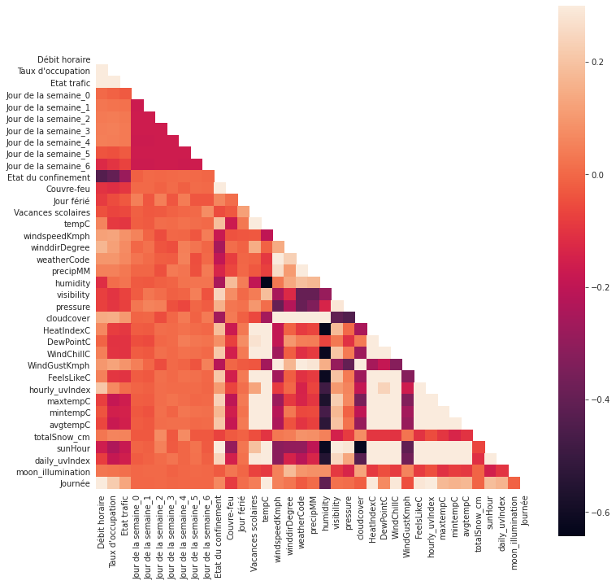

```python
corr = df.corr()
mask = np.zeros_like(corr)
mask[np.triu_indices_from(mask)] = True
with sns.axes_style("white"):
    plt.figure(figsize=(12,12))
    ax = sns.heatmap(corr, mask=mask, vmax=.3, square=True)
```

# Version concaténée du dataset

**Motivation :** Pour les besoins du modèle CNN, nous avons besoin d'un DataFrame avec les valeurs des 3 arcs à chaque ligne (et non pas une ligne par arc).

## Préliminaires

```python
for filename in list_filenames:
    print(f'{filename}')
    date_begin = df['Date et heure de comptage'][df['filename']==filename].min().strftime('%d/%m/%Y')
    date_end = df['Date et heure de comptage'][df['filename']==filename].max().strftime('%d/%m/%Y')
    print(f'Première mesure de comptage prise : {date_begin}')
    print(f'Dernière mesure de comptage prise : {date_end}')
    print(f'len: {len(df[df["filename"]==filename])}')
    print()
```

```
champs-elysees.csv
Première mesure de comptage prise : 01/11/2019
Dernière mesure de comptage prise : 11/12/2020
len: 9668

convention.csv
Première mesure de comptage prise : 01/11/2019
Dernière mesure de comptage prise : 11/12/2020
len: 9671

sts.csv
Première mesure de comptage prise : 01/11/2019
Dernière mesure de comptage prise : 11/12/2020
len: 9670
```

## Nettoyage

```python
list_filenames
```

```
['champs-elysees.csv', 'convention.csv', 'sts.csv']
```

```python
l_df = [df[df['filename']==elt] for elt in list_filenames]
l_df[0].head()
```

|  | Libelle | Date et heure de comptage | Débit horaire | Taux d'occupation | Etat trafic | Etat arc | filename | Date | Jour de la semaine_0 | Jour de la semaine_1 | ... | mintempC | avgtempC | totalSnow_cm | sunHour | daily_uvIndex | sunrise | sunset | moon_phase | moon_illumination | Journée |
| --- | --- | --- | --- | --- | --- | --- | --- | --- | --- | --- | --- | --- | --- | --- | --- | --- | --- | --- | --- | --- | --- |
| 0 | AV_Champs_Elysees | 2019-11-01 04:00:00 | 746.0 | 10.98889 | 1 | Invalide | champs-elysees.csv | 2019-11-01 | 0 | 0 | ... | 9 | 13 | 0.0 | 3.7 | 3 | 2019-11-01 07:37:00 | 2019-11-01 17:31:00 | Waxing Crescent | 24 | False |
| 1 | AV_Champs_Elysees | 2019-11-01 05:00:00 | 549.0 | 7.40722 | 1 | Invalide | champs-elysees.csv | 2019-11-01 | 0 | 0 | ... | 9 | 13 | 0.0 | 3.7 | 3 | 2019-11-01 07:37:00 | 2019-11-01 17:31:00 | Waxing Crescent | 24 | False |
| 2 | AV_Champs_Elysees | 2019-11-01 06:00:00 | 503.0 | 7.66667 | 1 | Invalide | champs-elysees.csv | 2019-11-01 | 0 | 0 | ... | 9 | 13 | 0.0 | 3.7 | 3 | 2019-11-01 07:37:00 | 2019-11-01 17:31:00 | Waxing Crescent | 24 | False |
| 3 | AV_Champs_Elysees | 2019-11-01 07:00:00 | 500.0 | 4.75500 | 1 | Invalide | champs-elysees.csv | 2019-11-01 | 0 | 0 | ... | 9 | 13 | 0.0 | 3.7 | 3 | 2019-11-01 07:37:00 | 2019-11-01 17:31:00 | Waxing Crescent | 24 | False |
| 4 | AV_Champs_Elysees | 2019-11-01 08:00:00 | 525.0 | 5.37389 | 1 | Invalide | champs-elysees.csv | 2019-11-01 | 0 | 0 | ... | 9 | 13 | 0.0 | 3.7 | 3 | 2019-11-01 07:37:00 | 2019-11-01 17:31:00 | Waxing Crescent | 24 | True |

5 rows × 47 columns

```python
l_cols_original = ['Débit horaire', "Taux d'occupation", "Etat trafic", "Etat arc"]

for idx, (cur_df, filename) in enumerate(zip(l_df, list_filenames)): # we skip the first dataframe
    l_cols_new = [filename[:-4] + '_' + elt for elt in l_cols_original]

    l_df[idx] = cur_df.rename(columns=dict(zip(l_cols_original, l_cols_new))).drop(columns=['Libelle'])

l_df[0].head()
```

|  | Date et heure de comptage | champs-elysees_Débit horaire | champs-elysees_Taux d'occupation | champs-elysees_Etat trafic | champs-elysees_Etat arc | filename | Date | Jour de la semaine_0 | Jour de la semaine_1 | Jour de la semaine_2 | ... | mintempC | avgtempC | totalSnow_cm | sunHour | daily_uvIndex | sunrise | sunset | moon_phase | moon_illumination | Journée |
| --- | --- | --- | --- | --- | --- | --- | --- | --- | --- | --- | --- | --- | --- | --- | --- | --- | --- | --- | --- | --- | --- |
| 0 | 2019-11-01 04:00:00 | 746.0 | 10.98889 | 1 | Invalide | champs-elysees.csv | 2019-11-01 | 0 | 0 | 0 | ... | 9 | 13 | 0.0 | 3.7 | 3 | 2019-11-01 07:37:00 | 2019-11-01 17:31:00 | Waxing Crescent | 24 | False |
| 1 | 2019-11-01 05:00:00 | 549.0 | 7.40722 | 1 | Invalide | champs-elysees.csv | 2019-11-01 | 0 | 0 | 0 | ... | 9 | 13 | 0.0 | 3.7 | 3 | 2019-11-01 07:37:00 | 2019-11-01 17:31:00 | Waxing Crescent | 24 | False |
| 2 | 2019-11-01 06:00:00 | 503.0 | 7.66667 | 1 | Invalide | champs-elysees.csv | 2019-11-01 | 0 | 0 | 0 | ... | 9 | 13 | 0.0 | 3.7 | 3 | 2019-11-01 07:37:00 | 2019-11-01 17:31:00 | Waxing Crescent | 24 | False |
| 3 | 2019-11-01 07:00:00 | 500.0 | 4.75500 | 1 | Invalide | champs-elysees.csv | 2019-11-01 | 0 | 0 | 0 | ... | 9 | 13 | 0.0 | 3.7 | 3 | 2019-11-01 07:37:00 | 2019-11-01 17:31:00 | Waxing Crescent | 24 | False |
| 4 | 2019-11-01 08:00:00 | 525.0 | 5.37389 | 1 | Invalide | champs-elysees.csv | 2019-11-01 | 0 | 0 | 0 | ... | 9 | 13 | 0.0 | 3.7 | 3 | 2019-11-01 07:37:00 | 2019-11-01 17:31:00 | Waxing Crescent | 24 | True |

5 rows × 46 columns

```python
def concat_reduce(df_1, df_2):
    filename = df_2['filename'].iloc[0][:-4]
    l_cols_original = ['Débit horaire', "Taux d'occupation", "Etat trafic", "Etat arc"]
    l_cols = ['Date et heure de comptage'] + [filename + '_' + elt for elt in l_cols_original]

    return df_1.merge(df_2[l_cols], on='Date et heure de comptage')

df_concat = reduce(concat_reduce, l_df)
df_concat = df_concat.sort_values(by='Date et heure de comptage')

df_concat.sample(10)
```

|  | Date et heure de comptage | champs-elysees_Débit horaire | champs-elysees_Taux d'occupation | champs-elysees_Etat trafic | champs-elysees_Etat arc | filename | Date | Jour de la semaine_0 | Jour de la semaine_1 | Jour de la semaine_2 | ... | moon_illumination | Journée | convention_Débit horaire | convention_Taux d'occupation | convention_Etat trafic | convention_Etat arc | sts_Débit horaire | sts_Taux d'occupation | sts_Etat trafic | sts_Etat arc |
| --- | --- | --- | --- | --- | --- | --- | --- | --- | --- | --- | --- | --- | --- | --- | --- | --- | --- | --- | --- | --- | --- |
| 1793 | 2020-01-14 21:00:00 | 1057.0 | 21.18723 | 2 | Invalide | champs-elysees.csv | 2020-01-14 | 0 | 1 | 0 | ... | 69 | False | 1086.0 | 24.23278 | 2 | Invalide | 1003.0 | 11.89333 | 1 | Invalide |
| 1457 | 2019-12-31 21:00:00 | 374.0 | 40.32833 | 3 | Barré | champs-elysees.csv | 2019-12-31 | 0 | 1 | 0 | ... | 26 | False | 1097.0 | 28.01167 | 2 | Invalide | 1008.0 | 12.63000 | 1 | Invalide |
| 5964 | 2020-07-08 16:00:00 | 1184.0 | 19.26056 | 2 | Invalide | champs-elysees.csv | 2020-07-08 | 0 | 0 | 1 | ... | 77 | True | 1046.0 | 23.39667 | 2 | Invalide | 759.0 | 10.62667 | 1 | Invalide |
| 7305 | 2020-09-02 13:00:00 | 1150.0 | 20.10500 | 2 | Invalide | champs-elysees.csv | 2020-09-02 | 0 | 0 | 1 | ... | 100 | True | 969.0 | 5.67778 | 1 | Invalide | 753.0 | 11.83611 | 1 | Invalide |
| 8116 | 2020-10-06 08:00:00 | 1301.0 | 15.44667 | 2 | Invalide | champs-elysees.csv | 2020-10-06 | 0 | 1 | 0 | ... | 67 | True | 822.0 | 6.74333 | 1 | Invalide | 726.0 | 11.31667 | 1 | Invalide |
| 1636 | 2020-01-08 08:00:00 | 1224.0 | 14.39111 | 1 | Invalide | champs-elysees.csv | 2020-01-08 | 0 | 0 | 1 | ... | 88 | False | 902.0 | 22.05000 | 2 | Invalide | 640.0 | 10.80722 | 1 | Invalide |
| 7474 | 2020-09-09 14:00:00 | 1121.0 | 24.16778 | 2 | Invalide | champs-elysees.csv | 2020-09-09 | 0 | 0 | 1 | ... | 43 | True | 878.0 | 5.38889 | 1 | Invalide | 762.0 | 11.77500 | 1 | Invalide |
| 2688 | 2020-02-21 04:00:00 | 366.0 | 4.45833 | 1 | Invalide | champs-elysees.csv | 2020-02-21 | 0 | 0 | 0 | ... | 0 | False | 133.0 | 0.62111 | 1 | Invalide | 95.0 | 1.13167 | 1 | Invalide |
| 8347 | 2020-10-15 23:00:00 | 622.0 | 7.62445 | 1 | Invalide | champs-elysees.csv | 2020-10-15 | 0 | 0 | 0 | ... | 2 | False | 491.0 | 2.50778 | 1 | Invalide | 609.0 | 6.62722 | 1 | Invalide |
| 6087 | 2020-07-13 19:00:00 | 884.0 | 15.50889 | 2 | Invalide | champs-elysees.csv | 2020-07-13 | 1 | 0 | 0 | ... | 41 | True | 748.0 | 4.03222 | 1 | Invalide | 569.0 | 5.94889 | 1 | Invalide |

10 rows × 54 columns

```python
len(df_concat)
```

```
9668
```

```python
df_concat.columns
```

```
Index(['Date et heure de comptage', 'champs-elysees_Débit horaire',
       'champs-elysees_Taux d'occupation', 'champs-elysees_Etat trafic',
       'champs-elysees_Etat arc', 'filename', 'Date', 'Jour de la semaine_0',
       'Jour de la semaine_1', 'Jour de la semaine_2', 'Jour de la semaine_3',
       'Jour de la semaine_4', 'Jour de la semaine_5', 'Jour de la semaine_6',
       'Etat du confinement', 'Couvre-feu', 'Jour férié', 'Vacances scolaires',
       'Date des prochaines vacances scolaires',
       'Temps avant les prochaines vacances scolaires', 'tempC',
       'windspeedKmph', 'winddirDegree', 'weatherCode', 'precipMM', 'humidity',
       'visibility', 'pressure', 'cloudcover', 'HeatIndexC', 'DewPointC',
       'WindChillC', 'WindGustKmph', 'FeelsLikeC', 'hourly_uvIndex',
       'maxtempC', 'mintempC', 'avgtempC', 'totalSnow_cm', 'sunHour',
       'daily_uvIndex', 'sunrise', 'sunset', 'moon_phase', 'moon_illumination',
       'Journée', 'convention_Débit horaire', 'convention_Taux d'occupation',
       'convention_Etat trafic', 'convention_Etat arc', 'sts_Débit horaire',
       'sts_Taux d'occupation', 'sts_Etat trafic', 'sts_Etat arc'],
      dtype='object')
```

For convenience, we'll know reorder the columns.

```python
columns_new_order = [
    'Date et heure de comptage', 'champs-elysees_Débit horaire',
    "champs-elysees_Taux d'occupation", 'champs-elysees_Etat trafic',
    'champs-elysees_Etat arc', 'convention_Débit horaire',
    "convention_Taux d'occupation", 'convention_Etat trafic',
    'convention_Etat arc', 'sts_Débit horaire', "sts_Taux d'occupation",
    'sts_Etat trafic', 'sts_Etat arc', 'filename', 'Date',
    'Jour de la semaine_0', 'Jour de la semaine_1', 'Jour de la semaine_2',
    'Jour de la semaine_3', 'Jour de la semaine_4', 'Jour de la semaine_5',
    'Jour de la semaine_6', 'Etat du confinement', 'Couvre-feu', 'Jour férié',
    'Vacances scolaires', 'Date des prochaines vacances scolaires',
    'Temps avant les prochaines vacances scolaires', 'tempC', 'windspeedKmph',
    'winddirDegree', 'weatherCode', 'precipMM', 'humidity', 'visibility',
    'pressure', 'cloudcover', 'HeatIndexC', 'DewPointC', 'WindChillC',
    'WindGustKmph', 'FeelsLikeC', 'hourly_uvIndex', 'maxtempC', 'mintempC',
    'avgtempC', 'totalSnow_cm', 'sunHour', 'daily_uvIndex', 'sunrise',
    'sunset', 'moon_phase', 'moon_illumination', 'Journée'
]

df_concat = df_concat[columns_new_order]
df_concat.head()
```

|  | Date et heure de comptage | champs-elysees_Débit horaire | champs-elysees_Taux d'occupation | champs-elysees_Etat trafic | champs-elysees_Etat arc | convention_Débit horaire | convention_Taux d'occupation | convention_Etat trafic | convention_Etat arc | sts_Débit horaire | ... | mintempC | avgtempC | totalSnow_cm | sunHour | daily_uvIndex | sunrise | sunset | moon_phase | moon_illumination | Journée |
| --- | --- | --- | --- | --- | --- | --- | --- | --- | --- | --- | --- | --- | --- | --- | --- | --- | --- | --- | --- | --- | --- |
| 0 | 2019-11-01 04:00:00 | 746.0 | 10.98889 | 1 | Invalide | 323.0 | 1.67722 | 1 | Invalide | 259.0 | ... | 9 | 13 | 0.0 | 3.7 | 3 | 2019-11-01 07:37:00 | 2019-11-01 17:31:00 | Waxing Crescent | 24 | False |
| 1 | 2019-11-01 05:00:00 | 549.0 | 7.40722 | 1 | Invalide | 272.0 | 1.41056 | 1 | Invalide | 197.0 | ... | 9 | 13 | 0.0 | 3.7 | 3 | 2019-11-01 07:37:00 | 2019-11-01 17:31:00 | Waxing Crescent | 24 | False |
| 2 | 2019-11-01 06:00:00 | 503.0 | 7.66667 | 1 | Invalide | 240.0 | 1.35667 | 1 | Invalide | 163.0 | ... | 9 | 13 | 0.0 | 3.7 | 3 | 2019-11-01 07:37:00 | 2019-11-01 17:31:00 | Waxing Crescent | 24 | False |
| 3 | 2019-11-01 07:00:00 | 500.0 | 4.75500 | 1 | Invalide | 216.0 | 1.14056 | 1 | Invalide | 170.0 | ... | 9 | 13 | 0.0 | 3.7 | 3 | 2019-11-01 07:37:00 | 2019-11-01 17:31:00 | Waxing Crescent | 24 | False |
| 4 | 2019-11-01 08:00:00 | 525.0 | 5.37389 | 1 | Invalide | 260.0 | 1.85722 | 1 | Invalide | 225.0 | ... | 9 | 13 | 0.0 | 3.7 | 3 | 2019-11-01 07:37:00 | 2019-11-01 17:31:00 | Waxing Crescent | 24 | True |

5 rows × 54 columns

```python
df_concat.columns
```

```
Index(['Date et heure de comptage', 'champs-elysees_Débit horaire',
       'champs-elysees_Taux d'occupation', 'champs-elysees_Etat trafic',
       'champs-elysees_Etat arc', 'convention_Débit horaire',
       'convention_Taux d'occupation', 'convention_Etat trafic',
       'convention_Etat arc', 'sts_Débit horaire', 'sts_Taux d'occupation',
       'sts_Etat trafic', 'sts_Etat arc', 'filename', 'Date',
       'Jour de la semaine_0', 'Jour de la semaine_1', 'Jour de la semaine_2',
       'Jour de la semaine_3', 'Jour de la semaine_4', 'Jour de la semaine_5',
       'Jour de la semaine_6', 'Etat du confinement', 'Couvre-feu',
       'Jour férié', 'Vacances scolaires',
       'Date des prochaines vacances scolaires',
       'Temps avant les prochaines vacances scolaires', 'tempC',
       'windspeedKmph', 'winddirDegree', 'weatherCode', 'precipMM', 'humidity',
       'visibility', 'pressure', 'cloudcover', 'HeatIndexC', 'DewPointC',
       'WindChillC', 'WindGustKmph', 'FeelsLikeC', 'hourly_uvIndex',
       'maxtempC', 'mintempC', 'avgtempC', 'totalSnow_cm', 'sunHour',
       'daily_uvIndex', 'sunrise', 'sunset', 'moon_phase', 'moon_illumination',
       'Journée'],
      dtype='object')
```